# Análise de Dados de Transcriptômica Espacial

Pré-processamento, Genes Espacialmente Variáveis e Visualização

Autor

Afiliação

Jonathan André Back

Mestrando, PPGBioinfo, UFPR

# 1 Quem sou eu

- Biomédico pela UFPR
- Especialização em Data Science & Big Data pela UFPR, concluída
- Especialização em Inteligência Artificial Generativa pela UFPR, em andamento
- Mestrando em Bioinformática, PPGBioinfo, UFPR
- Projeto: métodos estatísticos e computacionais para detectar **genes espacialmente variáveis**
- Ou seja: o tema de hoje é o meu dia a dia de pesquisa

## 1.1 Roteiro da aula

1. Transcriptômica espacial: Visium e o dataset `stxBrain`
2. Controle de qualidade e filtragem
3. Normalização e redução de dimensionalidade
4. Clusterização e visualização no Seurat
5. Expressão diferencial: SVG vs. DEG
6. Genes Espacialmente Variáveis: teoria e Moran’s I
7. Visualização: RGraphSpace + PathwaySpace

# 2 Abertura

## 2.1 O que muda com a espacialidade

- Single-cell RNA-seq: expressão gênica **sem localização**
- Spatial RNA-seq: expressão gênica **preservando a posição no tecido**
- Plataforma **Visium** (10x Genomics):
  - lâmina com milhares de *spots* de 55 µm
  - cada spot captura o transcriptoma daquele pedaço de tecido
- **Imagem histológica (H&E) como contexto**

## 2.2 Spot não é célula

- Single-cell: 1 barcode aprox. 1 célula
- Visium: 1 spot contém **de 1 a 10 células**
- Consequências:
  - QC, clusters e “células” do Seurat são, na prática, **spots**
  - Clusters se referem a **regiões teciduais**, não a tipos celulares
  - Métodos de single-cell funcionam, mas a **interpretação muda**

## 2.3 Do single-cell para o espacial

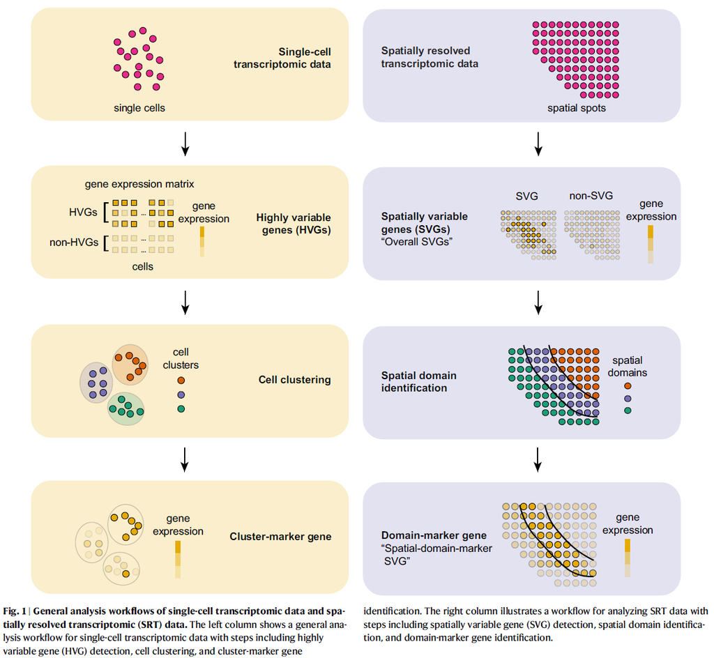

Fluxo comparativo de análise: single-cell vs. spatial transcriptomics. Fonte: Yan et al. 2025.

## 2.4 Dataset da aula: `stxBrain`

- Uma seção sagital **anterior** de cérebro de camundongo (10x Genomics)
  - `anterior1`: 2.696 spots
- Distribuído no pacote `SeuratData`
- Todo o pipeline de hoje roda nessa única seção

## 2.5 O objeto Seurat

- `assays`: matrizes de expressão (`Spatial`: counts e dados normalizados)
- `layers`: `counts`, `data`, `scale.data`
- `images`: coordenadas dos spots + imagem histológica
- `meta.data`: métricas por spot (`nCount_Spatial`, clusters)
- `reductions`: PCA, UMAP (criadas no pipeline)

## 2.6 Carregar os pacotes

**Código**

```r
# CRAN
if (!require("Seurat"))        install.packages("Seurat")
if (!require("SeuratData"))    install.packages("SeuratData")
if (!require("ggplot2"))       install.packages("ggplot2")
if (!require("patchwork"))     install.packages("patchwork")
if (!require("dplyr"))         install.packages("dplyr")

# Visualizacao (Sysbiolab)
if (!require("RGraphSpace"))   install.packages("RGraphSpace")
if (!require("PathwaySpace"))  install.packages("PathwaySpace")

library("Seurat")
library("SeuratData")
library("ggplot2")
library("patchwork")
library("dplyr")
library("RGraphSpace")
library("PathwaySpace")
```

## 2.7 Carregar os dados

**Código**

```r
if (!require("stxBrain.SeuratData")) {
  SeuratData::InstallData("stxBrain")
}

brain <- SeuratData::LoadData("stxBrain", type = "anterior1")
```

**Código**

```r
dim(brain)   # genes x spots
```

```
[1] 31053  2696
```

# 3 Controle de qualidade

## 3.1 O que medir por spot

- `nCount_Spatial`: total de transcritos (UMIs) no spot
- `nFeature_Spatial`: número de genes detectados no spot
- Pergunta do QC: **meus spots representam tecido íntegro?**
- Particularidade do espacial:
  - QC é consolidado em single-cell, ainda pouco padronizado em espacial
  - usaremos **critérios simples e transparentes**

## 3.2 Inspecionar as métricas

**Código**

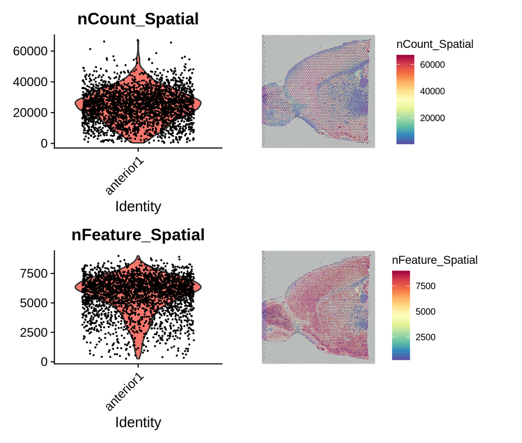

```r
plot1 <- VlnPlot(brain, features = "nCount_Spatial", pt.size = 0.1) + NoLegend()
plot2 <- SpatialFeaturePlot(brain, features = "nCount_Spatial") +
  theme(legend.position = "right")

plot3 <- VlnPlot(brain, features = "nFeature_Spatial", pt.size = 0.1) + NoLegend()
plot4 <- SpatialFeaturePlot(brain, features = "nFeature_Spatial") +
  theme(legend.position = "right")

wrap_plots(plot1, plot2, plot3, plot4, ncol = 2)
```

## 3.3 Decidir o limiar com um histograma

**Código**

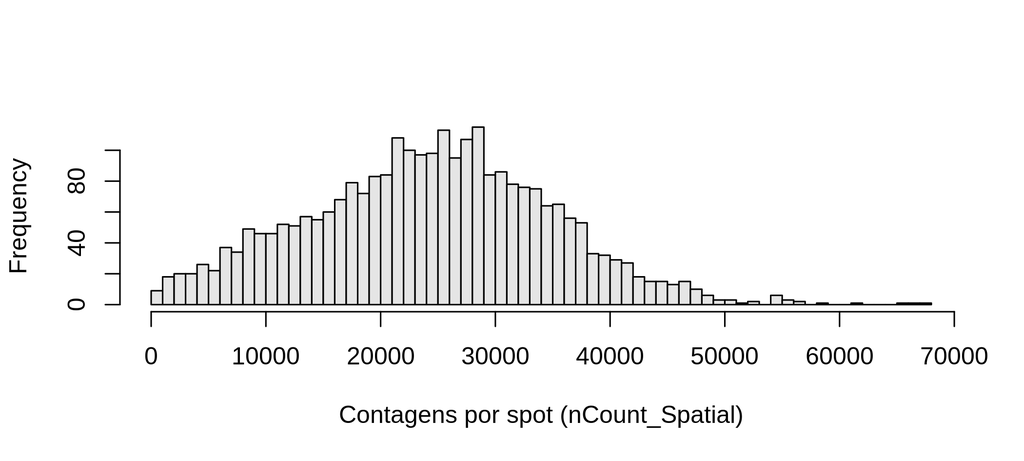

```r
hist(
  brain$nCount_Spatial,
  breaks = 60,
  col  = "grey90",
  main = "",
  xlab = "Contagens por spot (nCount_Spatial)"
)
```

- Onde começa a cauda de spots com pouquíssimas contagens?
- Decisão **olhando os dados**, sem número mágico

## 3.4 Filtragem: dois critérios simples

**Código**

```r
# 1) Genes detectados em pelo menos 1% dos spots
n_spots  <- ncol(brain)
genes_ok <- rowSums(GetAssayData(brain, layer = "counts") > 0) >= 0.01 * n_spots

brain <- brain[genes_ok, ]

# 2) Spots acima do limiar decidido no histograma
limiar_counts <- 100
brain <- subset(brain, subset = nCount_Spatial > limiar_counts)
```

**Código**

```r
dim(brain)                        # depois dos filtros
```

```
[1] 15117  2696
```

**Código**

```r
quantile(brain$nCount_Spatial)    # distribuicao de contagens que seguem
```

```
      0%      25%      50%      75%     100%
  353.00 17099.00 24511.00 31468.25 67119.00
```

# 4 Normalização

## 4.1 Por que normalizar

- Profundidade de sequenciamento varia entre spots:
  - causas técnicas: captura, eficiência
  - causas biológicas: densidade celular, tecido
- Objetivo: **tornar spots comparáveis** sem apagar o sinal biológico

## 4.2 LogNormalize vs. SCTransform

|  | LogNormalize | SCTransform |
| --- | --- | --- |
| O que faz | counts / total x 10.000, depois log1p | modelo por gene, Pearson residuals |
| Complexidade | baixa, transparente | alta, mais lenta |
| Indicado para | didático, inspeção | produção, grandes conjuntos |

- Hoje: **LogNormalize**
  - rápida e de leitura fácil
  - implementada nativamente no fluxo padrão do Seurat

## 4.3 Três passos explícitos

**Código**

```r
# 1) Normalizacao por spot
brain <- NormalizeData(brain)
```

**Código**

```r
# 2) Selecionar genes variaveis (entrada da PCA)
brain <- FindVariableFeatures(brain)
```

**Código**

```r
# 3) Scaling por gene (z-score), cria a layer scale.data usada pela PCA
brain <- ScaleData(brain)
```

## 4.4 Conferir genes conhecidos no tecido

**Código**

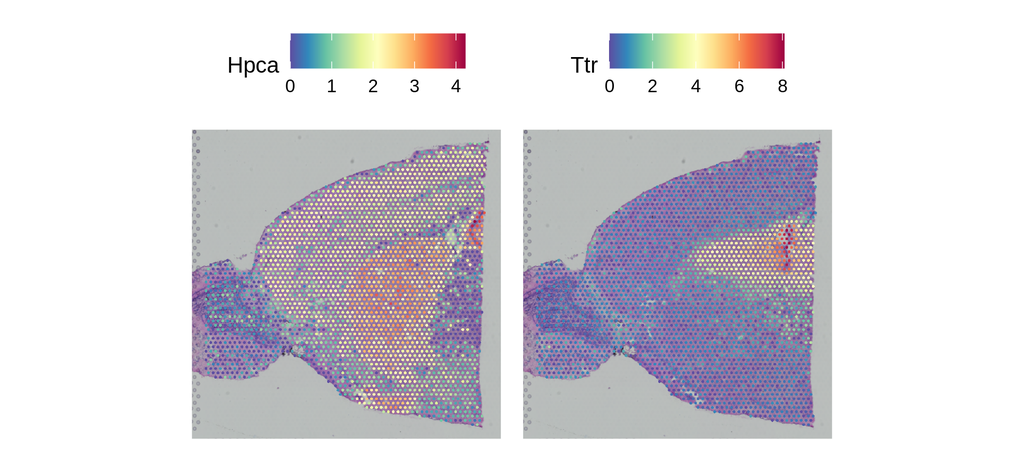

```r
SpatialFeaturePlot(brain, features = c("Hpca", "Ttr"))
```

- `Hpca`: marcador do hipocampo
- `Ttr`: plexo coroide
- Checagem anatômica: o dado faz sentido no tecido?

# 5 Redução de dimensionalidade

## 5.1 PCA

**Código**

```r
brain <- RunPCA(brain, assay = "Spatial", verbose = FALSE)
```

- Resume milhares de genes nas **principais fontes de variação** (PCs ranqueadas)
- As top PCs alimentam UMAP e clusterização
- Hoje usamos as **30 primeiras PCs**, um valor que faz sentido para Visium

## 5.2 UMAP

**Código**

```r
brain <- RunUMAP(brain, reduction = "pca", dims = 1:30)
```

- Método **não linear** para visualizar em 2D
- t-SNE: alternativa, mesma função (não rodaremos hoje)

# 6 Clusterização

## 6.1 A ideia

- Delimitar **regiões teciduais** para análise compartimentada
- Estratégia padrão (teoria de grafos):
  - grafo de vizinhança **K-Nearest Neighbors** no espaço das PCs
  - detecção de comunidades (Louvain) no grafo **Shared Nearest Neighbors**
- `resolution`: granularidade da busca
  - baixa, menos clusters; alta, mais clusters

## 6.2 Na prática

**Código**

```r
set.seed(2026)

brain <- FindNeighbors(brain, reduction = "pca", dims = 1:30)
brain <- FindClusters(brain, verbose = FALSE)

table(brain$seurat_clusters)
```

```
  0   1   2   3   4   5   6   7   8   9  10  11  12  13  14  15  16  17
429 242 241 223 196 186 177 166 156 143 132 105  86  82  41  37  30  24
```

## 6.3 Clusters no tecido

**Código**

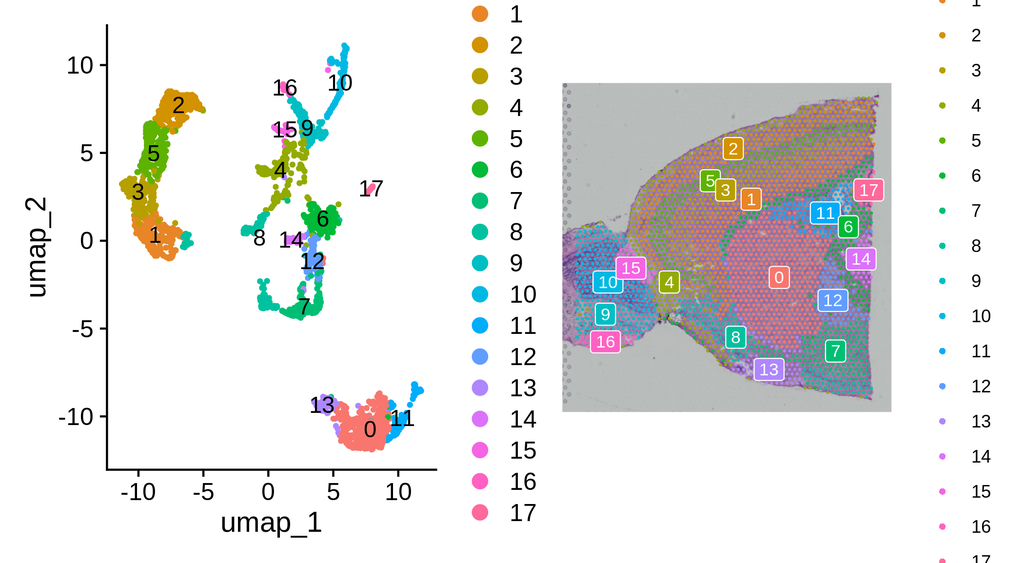

```r
p1 <- DimPlot(brain, reduction = "umap", label = TRUE)

p2 <- SpatialDimPlot(brain, label = TRUE, label.size = 3)

p1 + p2
```

- Clusters que formam **regiões organizadas** no tecido: sinal de que o pipeline faz sentido

## 6.4 Cada cluster no tecido

**Código**

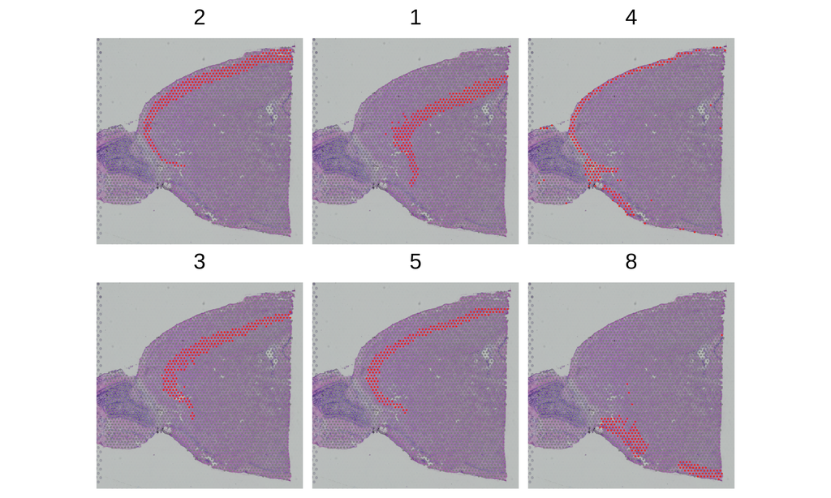

```r
SpatialDimPlot(
  brain,
  cells.highlight = CellsByIdentities(object = brain, idents = c(2, 1, 4, 3, 5, 8)),
  facet.highlight = TRUE,
  ncol = 3
) & theme(plot.margin = unit(c(1, 1, 1, 1), "mm"))
```

## 6.5 Intervalo

Na volta: **Genes Espacialmente Variáveis**, o núcleo da aula.

# 7 Expressão diferencial

## 7.1 Espacialmente variável (SVG) vs. Diferencialmente expresso (DEG)

|  | DEG | SVG |
| --- | --- | --- |
| Pergunta | diferença entre dois grupos? | a expressão depende da posição XY? |
| Referência | precisa de grupos pré-definidos | não precisa de grupos |
| Natureza | relativa | absoluta |

- Vamos rodar uma **DE** agora para depois contrastar com os **SVGs**

## 7.2 FindMarkers na prática

**Código**

```r
de_markers <- FindMarkers(brain, ident.1 = 3, ident.2 = 4)

de_markers <- de_markers[order(de_markers$p_val_adj), ]
head(de_markers, 10)
```

```
              p_val avg_log2FC pct.1 pct.2    p_val_adj
Snap25 8.065681e-70  1.6367725     1 0.995 1.219289e-65
Calm2  4.608855e-69  1.2386649     1 1.000 6.967205e-65
Apoe   3.511522e-68 -1.4998540     1 1.000 5.308367e-64
Snrpn  5.418991e-66  1.2696835     1 0.980 8.191889e-62
Pcp4   8.044878e-66  1.7224564     1 0.954 1.216144e-61
Uchl1  2.564357e-64  1.4350402     1 0.954 3.876539e-60
Vsnl1  1.450798e-63  1.6626500     1 0.918 2.193171e-59
Cst3   4.984477e-63 -0.9375573     1 1.000 7.535033e-59
Scn1b  8.462865e-63  1.4724698     1 0.969 1.279331e-58
Chn1   2.617018e-60  1.4554168     1 0.949 3.956147e-56
```

Colunas do resultado:

- `p_val`: p-valor do teste (Wilcoxon por padrão)
- `avg_log2FC`: log fold-change médio; positivo, mais expresso no cluster 3; negativo, mais expresso no cluster 4
- `pct.1` e `pct.2`: percentual de spots que detectam o gene em cada cluster
- `p_val_adj`: p-valor ajustado (Bonferroni)

## 7.3 Visualizar os DEGs

**Código**

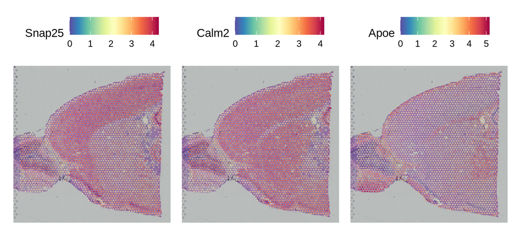

```r
SpatialFeaturePlot(
  object = brain,
  features = rownames(de_markers)[1:3],
  alpha = c(0.1, 1),
  ncol = 3
)
```

# 8 Genes Espacialmente Variáveis

## 8.1 O que é um SVG

- **Spatially Variable Gene**
- Gene cuja **distribuição de expressão depende da posição** no tecido
- A expressão não é aleatória no espaço: segue um **padrão tecidual**

## 8.2 Padrões espaciais de SVGs

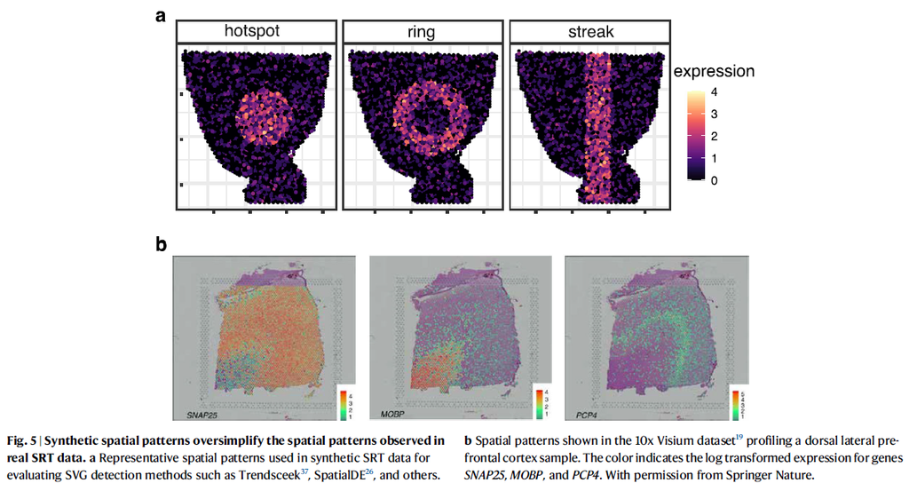

Padrões: hotspot, ring, streak e exemplos reais. Fonte: Yan et al. 2025.

## 8.3 SVG não é DEG

- DEG: precisa de grupos definidos para comparar
- SVG: detectado **sem qualquer agrupamento**, usando apenas expressão + XY
- Um gene pode ser:
  - SVG e DEG: padrão espacial que coincide com um cluster
  - SVG sem DEG: gradiente contínuo, sem grupos definidos
  - DEG sem SVG: diferença entre regiões, padrão interno aleatório

## 8.4 Três categorias de SVGs

- **Overall**: padrão não aleatório no tecido inteiro, nosso foco hoje
- **Cell-type-specific**: variação espacial dentro de um tipo celular (CTSV, C-SIDE, spVC)
- **Spatial-domain-marker**: enriquecido em um domínio espacial (SpaGCN, DESpace)

## 8.5 As três categorias em detalhe

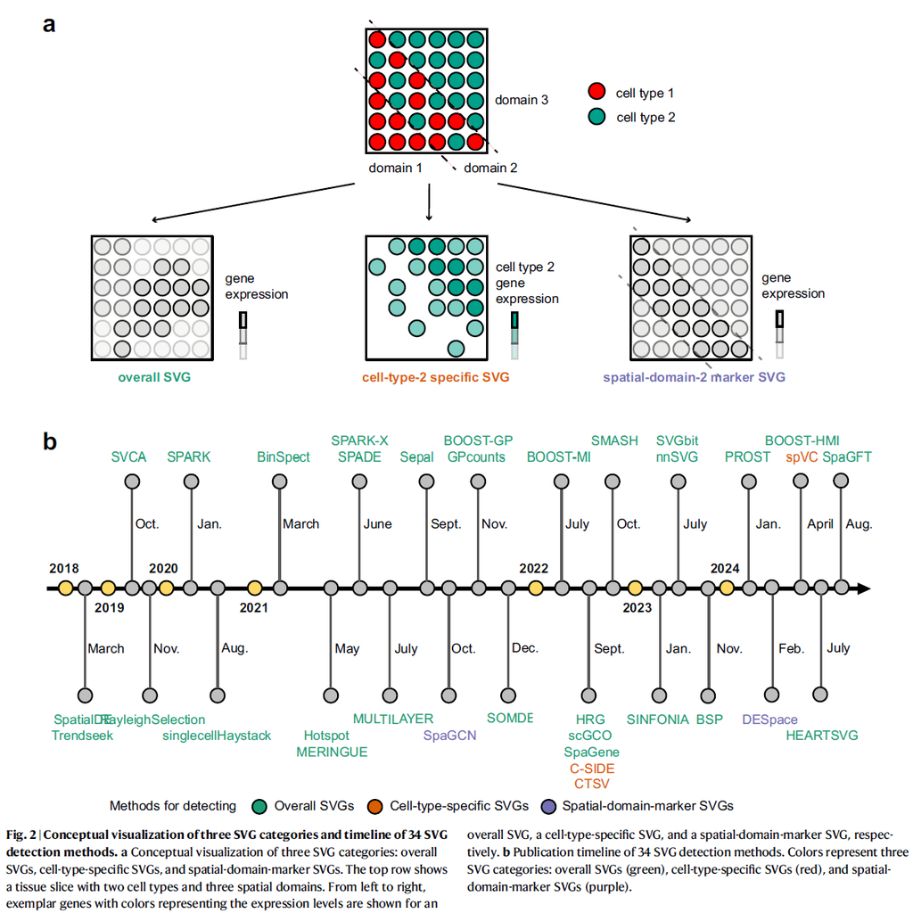

Categorias de SVGs e linha do tempo dos métodos. Fonte: Yan et al. 2025, Nature Communications.

## 8.6 Muitos métodos, pouco consenso

- 34 métodos revisados, várias abordagens estatísticas
- Sem consenso sobre qual usar
- Por isso existem **benchmarks** comparativos

## 8.7 Os 34 métodos em detalhe

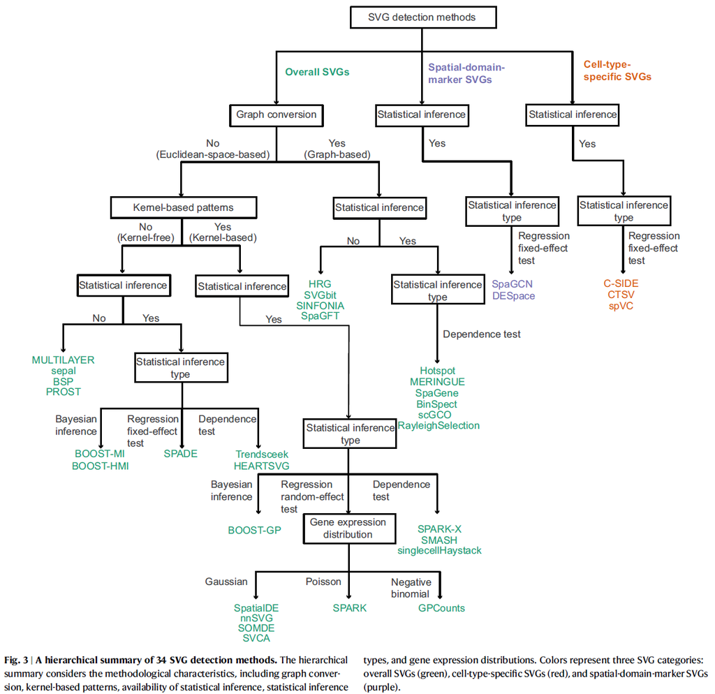

Árvore dos 34 métodos de SVG organizados nas três famílias. Fonte: Yan et al. 2025, Nature Communications.

## 8.8 O que dizem os benchmarks

- Charitakis et al. (2023): número de SVGs varia **1 a 2 ordens de magnitude** entre pacotes no mesmo tecido
- Chen et al. (2024): métodos selecionam **conjuntos muito diferentes** de SVGs
- Li et al. (2025): **SPARK-X** com o melhor desempenho geral; **Moran’s I** baseline competitivo
- Na prática:
  - não há consenso: conheça as limitações do método que você usa
  - valide sempre com plausibilidade biológica e o olhar no tecido
- Hoje na prática: **Moran’s I**, implementado direto no Seurat

## 8.9 Moran’s I: a ideia

- Estatística de **autocorrelação espacial**
- Pergunta: spots vizinhos têm expressão **similar**?
  - I positivo: padrão espacial estruturado
  - I próximo de zero: expressão aleatória no espaço
- Implementado no Seurat: `FindSpatiallyVariableFeatures(selection.method = "moransi")`

## 8.10 Moran’s I na prática

**Código**

```r
brain <- FindSpatiallyVariableFeatures(
  brain,
  features = VariableFeatures(brain)[1:100],
  selection.method = "moransi"
)

top_moransi <- head(SpatiallyVariableFeatures(brain, method = "moransi"), 6)
top_moransi
```

```
[1] "Calb2"  "S100a5" "Gng4"   "Cck"    "Ttr"    "Doc2g"
```

**Código**

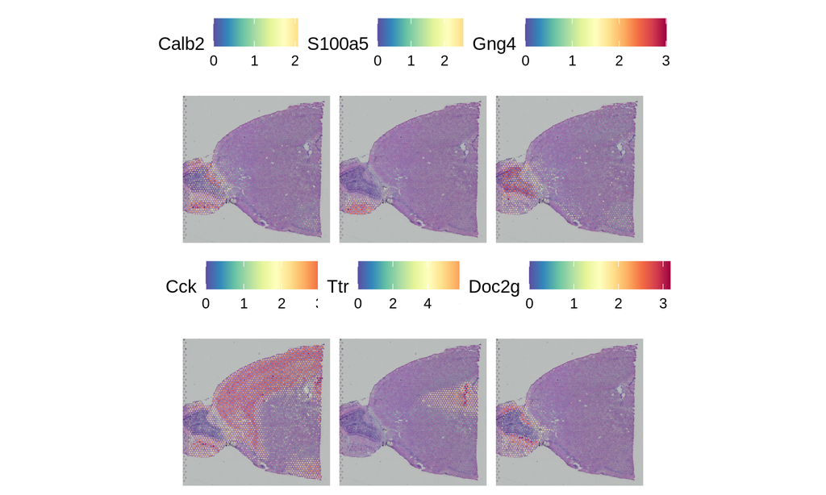

```r
SpatialFeaturePlot(brain, features = top_moransi, ncol = 3, alpha = c(0.1, 1)) &
  theme(plot.margin = unit(c(1, 1, 1, 1), "mm"))
```

## 8.11 Interpretação biológica

- Para cada top gene, perguntar:
  - o padrão é **anatômico**? (camada cortical, plexo coroide, região)
  - é **gradiente contínuo** ou domínio discreto?
  - faz sentido para o **cérebro de camundongo**?
- Nenhuma estatística substitui o **olhar no tecido**

# 9 RGraphSpace + PathwaySpace

## 9.1 Motivação

- Seurat plota a expressão **nos spots**: círculos discretos
- Entre os spots, espaço vazio: a biologia não é discreta
- Pacotes do **Sysbiolab** (UFPR) para visualizar o sinal de forma contínua
- Fio condutor: visualizar **os top SVGs** do Moran’s I

## 9.2 RGraphSpace: o que é

- Renderiza grafos como **objetos espaciais coerentes no ggplot2**
- Três geoms dedicados:
  - `geom_nodespace()`: nós (nossos spots)
  - `geom_edgespace()`: conexões
  - `geom_graphspace()`: os dois juntos
- **Alinhamento espacial a nível de pixel**: nós ancorados aos centros dos pixels da imagem
- É a infraestrutura que o PathwaySpace usa por baixo

## 9.3 PathwaySpace: o que é

- Projeção espacial de sinais de rede ao longo de **caminhos geodésicos**
- A operação central é uma **convolução**:
  - posições com sinal (spots) são **transmissores**
  - posições sem sinal (espaço entre spots) são **receptores**
- Dois ajustes do usuário:
  - **decaimento**: como o sinal atenua com a distância (linear, exponencial, Weibull)
  - **agregação**: como combinar os k sinais vizinhos (média, média ponderada)

## 9.4 RGraphSpace: coerção a partir do Seurat

**Código**

```r
# Fluxo recomendado: extrai coordenadas e expressao de uma so vez
gs <- as.GraphSpace(brain, space = "spatial", scale = "lowres")

# A imagem histologica e atribuida em um passo separado
gs_image(gs) <- SeuratObject::GetImage(brain, mode = "raster")

# Alinha spots e imagem no nivel do pixel (flip.y ja e aplicado por padrao)
gs <- normalizeGraphSpace(gs, swap.xy=T)
```

## 9.5 Conferir a sobreposição

**Código**

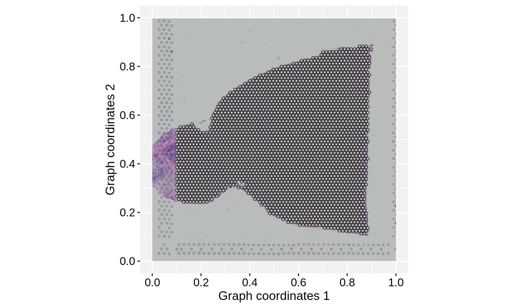

```r
plotGraphSpace(gs, add.image = TRUE)
```

## 9.6 Reproduzindo a visualização do Seurat

**Código**

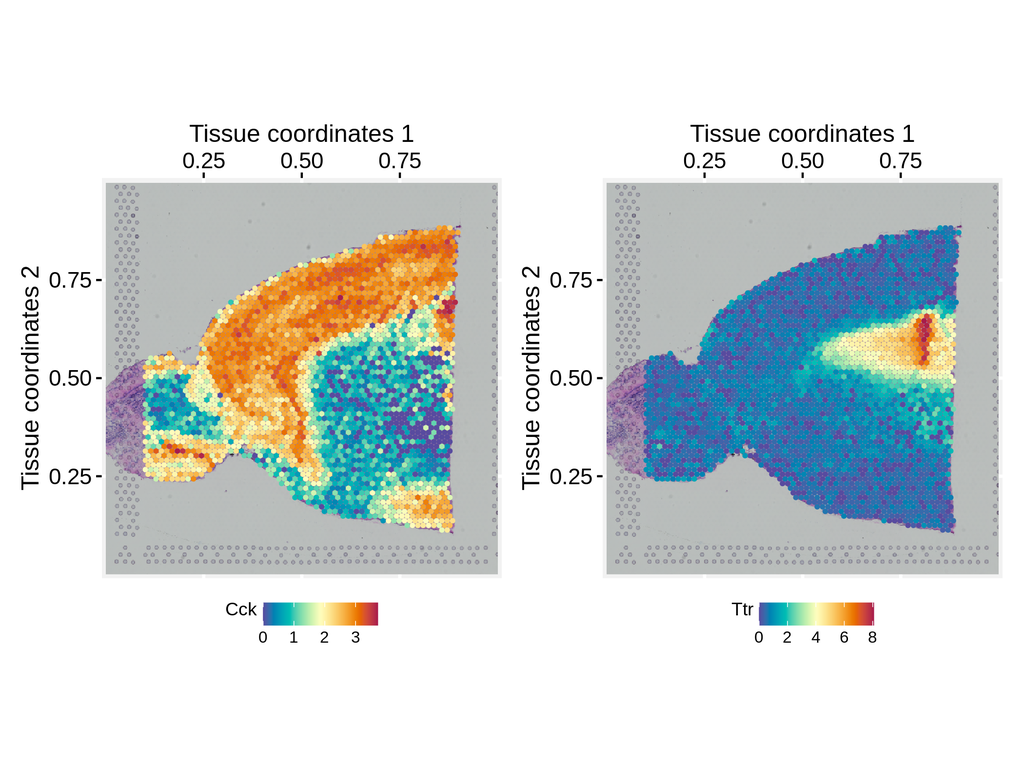

```r
cpal <- hcl.colors(100, palette = "Spectral", rev = TRUE)

p1 <- ggplot(gs) +
  annotation_gspace_image(gs) +
  geom_nodespace(mapping = aes(colour = Cck), size = 1, pch = 19) +
  scale_colour_continuous(palette = cpal) +
  theme_gspace_coords(theme = "th3", is_norm = TRUE,
                      xlab = "Tissue coordinates 1", ylab = "Tissue coordinates 2")

p2 <- ggplot(gs) +
  annotation_gspace_image(gs) +
  geom_nodespace(mapping = aes(colour = Ttr), size = 1, pch = 19) +
  scale_colour_continuous(palette = cpal) +
  theme_gspace_coords(theme = "th3", is_norm = TRUE,
                      xlab = "Tissue coordinates 1", ylab = "Tissue coordinates 2")

p1 + p2
```

- Mesma lógica do `SpatialFeaturePlot`, agora no sistema de coordenadas do RGraphSpace

## 9.7 Clusters no RGraphSpace

**Código**

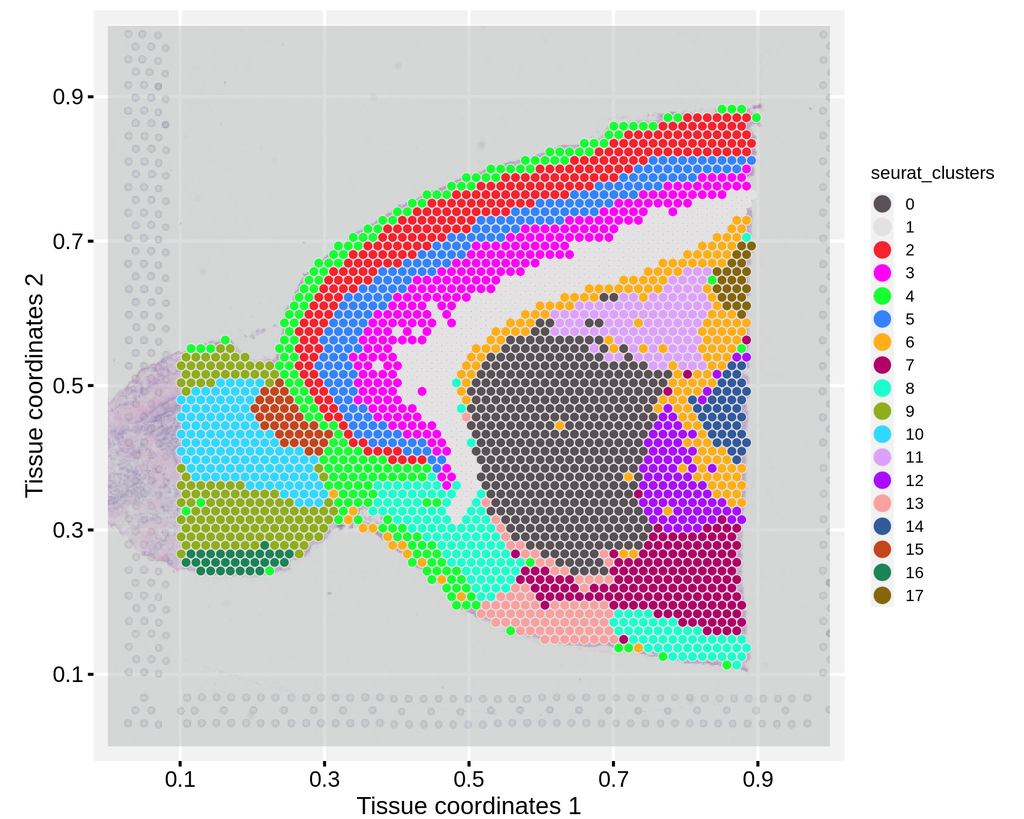

```r
cpal_clusters <- DiscretePalette(nlevels(gs$seurat_clusters), palette = "polychrome")

ggplot(gs) +
  annotation_gspace_image(gs, opacity = 0.5) +
  geom_nodespace(mapping = aes(fill = seurat_clusters),
                 size = 1.3, color = "grey90", stroke = 0.3) +
  scale_fill_manual(values = cpal_clusters) +
  theme_gspace_coords(theme = "th2", is_norm = TRUE,
                      xlab = "Tissue coordinates 1", ylab = "Tissue coordinates 2") +
  theme_gspace_legend(discrete_fill = TRUE)
```

## 9.8 PathwaySpace: construir e medir distâncias

**Código**

```r
pspace_obj <- buildPathwaySpace(gs)

# PathwaySpace estende a classe GraphSpace
inherits(pspace_obj, "GraphSpace")
```

```
[1] TRUE
```

**Código**

```r
class(pspace_obj)
```

```
[1] "PathwaySpace"
attr(,"package")
[1] "PathwaySpace"
```

**Código**

```r
# Distancia media de cada spot ao vizinho mais proximo
nspot <- getNearestNode(pspace_obj)
pdist <- mean(nspot$dist)
pdist
```

```
[1] 0.0135778
```

- Em Visium, `pdist` equivale aos **100 µm** entre centros de spots

## 9.9 Mapear a silhueta

**Código**

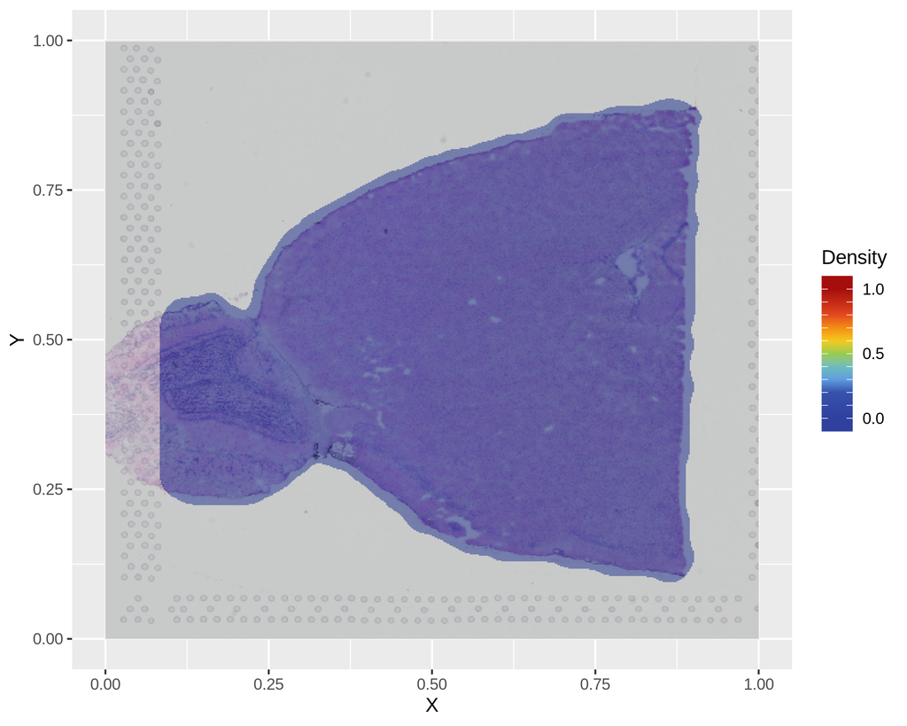

```r
# A silhueta delimita a area sobre a qual o sinal sera projetado
pspace_obj <- silhouetteMapping(pspace_obj, baseline = 0.1)

ggplot(pspace_obj) +
  annotation_gspace_image(pspace_obj) +
  annotation_pspace_signal(pspace_obj, si.alpha = 0.5)
```

- `baseline` controla a extensão da representação

## 9.10 Projetar o sinal

**Código**

```r
gene_sv <- top_moransi[1]

# O sinal de cada spot e difundido no espaco continuo,
# ponderado pela distancia (decaimento) e agregado (media ponderada)
activeFeature(pspace_obj) <- gene_sv

pspace_obj <- circularProjection(
  pspace_obj,
  k = gs_vcount(pspace_obj),
  decay.fun = weibullDecay(decay = 0.5, pdist = pdist),
  aggregate.fun = signalAggregation("wmean")
)
```

## 9.11 Visualizar as projeções

**Código**

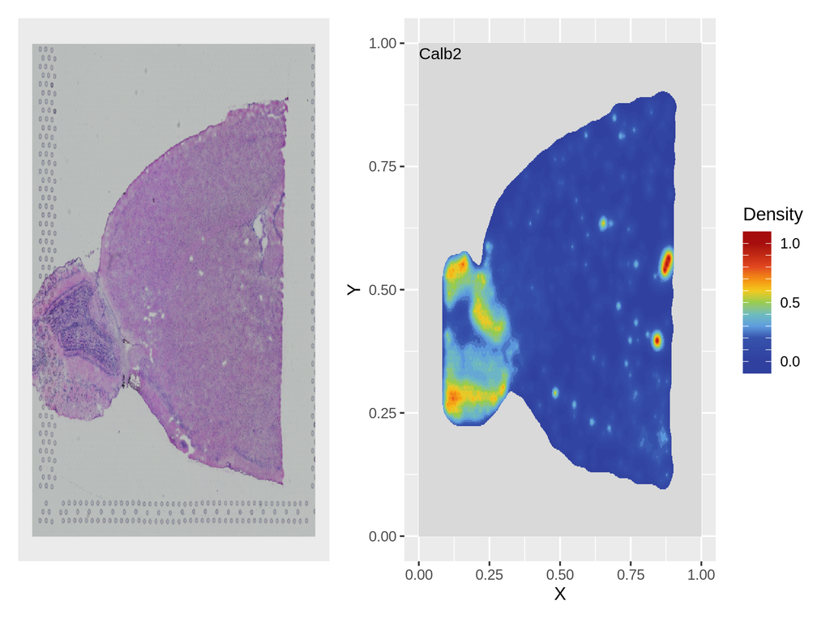

```r
# Esquerda: so a imagem do tecido, sem sinal
p1 <- ggplot(pspace_obj) +
  annotation_gspace_image(pspace_obj)

# Direita: sinal projetado sobre a imagem
p2 <- ggplot(pspace_obj) +
  annotation_gspace_image(pspace_obj) +
  annotation_pspace_signal(pspace_obj, si.alpha = 1)

p1 + p2
```

- `gene_sv`: o top 1 do Moran’s I, imagem vs. sinal projetado

## 9.12 Top 6 SVGs do Moran’s I projetados

**Código**

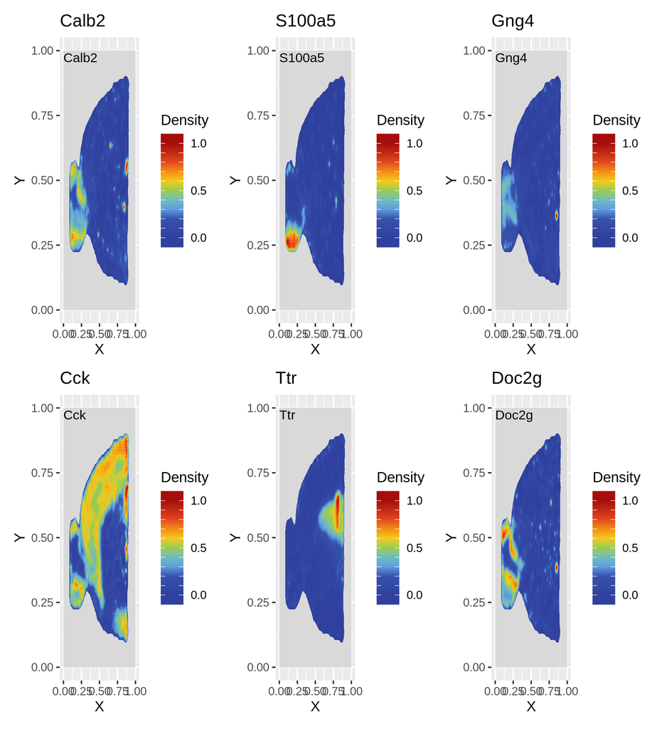

```r
paineis <- list()

for (gene in top_moransi) {
  activeFeature(pspace_obj) <- gene
  pspace_obj <- circularProjection(
    pspace_obj,
    k = gs_vcount(pspace_obj),
    decay.fun = weibullDecay(decay = 0.5, pdist = pdist),
    aggregate.fun = signalAggregation("wmean")
  )
  paineis[[gene]] <- ggplot(pspace_obj) +
    annotation_gspace_image(pspace_obj) +
    annotation_pspace_signal(pspace_obj, si.alpha = 1) +
    labs(title = gene)
}

wrap_plots(paineis, ncol = 3)
```

## 9.13 Painel final

**Código**

[figure not shown]

```r
g_seurat <- SpatialFeaturePlot(
  brain,
  features = gene_sv,
  alpha = c(0.1, 1)
) + labs(title = "Seurat")

g_rgs <- ggplot(gs) +
  annotation_gspace_image(gs) +
  geom_nodespace(aes(colour = !!rlang::sym(gene_sv)), size = 1, pch = 19) +
  scale_colour_continuous(palette = cpal) +
  theme_gspace_coords(theme = "th3", is_norm = TRUE) +
  labs(title = "RGraphSpace")

activeFeature(pspace_obj) <- gene_sv
pspace_obj <- circularProjection(
  pspace_obj,
  k = gs_vcount(pspace_obj),
  decay.fun = weibullDecay(decay = 0.5, pdist = pdist),
  aggregate.fun = signalAggregation("wmean")
)
p_final <- ggplot(pspace_obj) +
  annotation_gspace_image(pspace_obj) +
  annotation_pspace_signal(pspace_obj, si.alpha = 1) +
  labs(title = "PathwaySpace")

g_seurat + g_rgs + p_final
```

- Discussão: o que cada representação revela e o que esconde?

# 10 Fechamento

## 10.1 O que vimos hoje

- Pipeline Seurat espacial: QC, LogNormalize, PCA, UMAP, clusters
- **SVG não é DEG**
- Divisão dos métodos de detecção de SVGs em três categorias
- Moran’s I na prática, com exploração e interpretação dos resultados
- **Visualização contínua** dos SVGs com RGraphSpace + PathwaySpace

## 10.2 Referências principais

- Stuart et al. (2019). *Cell*. Seurat V3.
- Hafemeister e Satija (2019). *Genome Biology*. SCTransform.
- Svensson et al. (2018). *Nature Methods*. SpatialDE.
- Zhu, Sun e Zhou (2021). *Genome Biology*. SPARK-X.
- Weber et al. (2023). *Nature Communications*. nnSVG.
- Charitakis et al. (2023). *Genome Biology*. Disparities in SVG calling.
- Chen et al. (2024). *Genome Biology*. Evaluating SVG detection methods.
- Yan et al. (2025). *Nature Communications*. Categorização de 34 métodos.
- Li et al. (2025). *Genome Biology*. Benchmark sistemático de SVGs.
- Yao et al. (2026). *Briefings in Bioinformatics*. Benchmark de ctSVGs.
- Kang et al. (2025). *Nucleic Acids Research*. Domínios espaciais.
- Tercan e Apolonio et al. (2025). *STAR Protocols*. PathwaySpace.
- RGraphSpace (2025). *JOSS*. doi 10.21105/joss.11209

## 10.3 Próximos passos

- Roteiro HTML desta aula para execução no RStudio
- Material de apoio no canal do curso

## 10.4 Obrigado

Dúvidas?